# Homework 12 - Support Vector Machines

Shuang Du

04/13/2022

# Credit card dataset

We will be working in this homework with a popular machine learning dataset about credit card fraud. Go to the following link and download the CSV:

https://www.openml.org/d/1597

The data description is

> The datasets contains transactions made by credit cards in September 2013 by european cardholders. This dataset present transactions that occurred in two days, where we have 492 frauds out of 284,807 transactions. The dataset is highly unbalanced, the positive class (frauds) account for 0.172% of all transactions.

Now we begin by reading into R:

```r
library(readr)
library(foreign)
z <- read.arff('data.arff')
```

```r
dim(z)
```

```
## [1] 284807     31
```

```r
table(z$Class)
```

```
##
##      0      1
## 284315    492
```

```r
y <- gsub("\\'","",z$Class)
x <- as.data.frame(z[,-31])
```

We will deal with the class imbalance for this homework just by downsampling the non-fraud cases. As we saw in the random forest homework there are other approaches including custom cost functions.

```r
set.seed(1)
idx <- c(sample(which(y == "0"), sum(y == "1")), which(y == "1"))
y <- y[idx]
x <- as.data.frame(scale(x[idx,]))
table(y)
```

```
## y
##   0   1
## 492 492
```

### 1

The homework assignment is to run linear and radial basis function SVM on the dataset, and report the Kappa for both models. For RBF, you should plot the Kappa over the different values for the cost function (`metric="Kappa"`).

```r
library(caret)
# fit inear SVM
tg <- data.frame(C=seq(0.1,2,0.1))
linearSVM <- train(x, y, method="svmLinear", tuneGrid=tg)
linearSVM$results
```

```
##      C  Accuracy     Kappa  AccuracySD    KappaSD
## 1  0.1 0.9353057 0.8705349 0.008108943 0.01619435
## 2  0.2 0.9359561 0.8718363 0.007718584 0.01540512
## 3  0.3 0.9362848 0.8724813 0.008442352 0.01689124
## 4  0.4 0.9363147 0.8725348 0.008724804 0.01747777
## 5  0.5 0.9372071 0.8743205 0.008624086 0.01726448
## 6  0.6 0.9377579 0.8754130 0.008707905 0.01743976
## 7  0.7 0.9369940 0.8738865 0.008536334 0.01710919
## 8  0.8 0.9366635 0.8732250 0.008398677 0.01682461
## 9  0.9 0.9358942 0.8716834 0.008417743 0.01684703
## 10 1.0 0.9368740 0.8736493 0.007700727 0.01539714
## 11 1.1 0.9367685 0.8734376 0.007444132 0.01488256
## 12 1.2 0.9363072 0.8725129 0.007986591 0.01595838
## 13 1.3 0.9364393 0.8727796 0.007539509 0.01505847
## 14 1.4 0.9357661 0.8714310 0.007413775 0.01480458
## 15 1.5 0.9355317 0.8709590 0.007556076 0.01510264
## 16 1.6 0.9357428 0.8713826 0.008064991 0.01612857
## 17 1.7 0.9355273 0.8709522 0.007588730 0.01517787
## 18 1.8 0.9356374 0.8711743 0.008157030 0.01629873
## 19 1.9 0.9353121 0.8705243 0.007770646 0.01551940
## 20 2.0 0.9350844 0.8700677 0.007867913 0.01571952
```

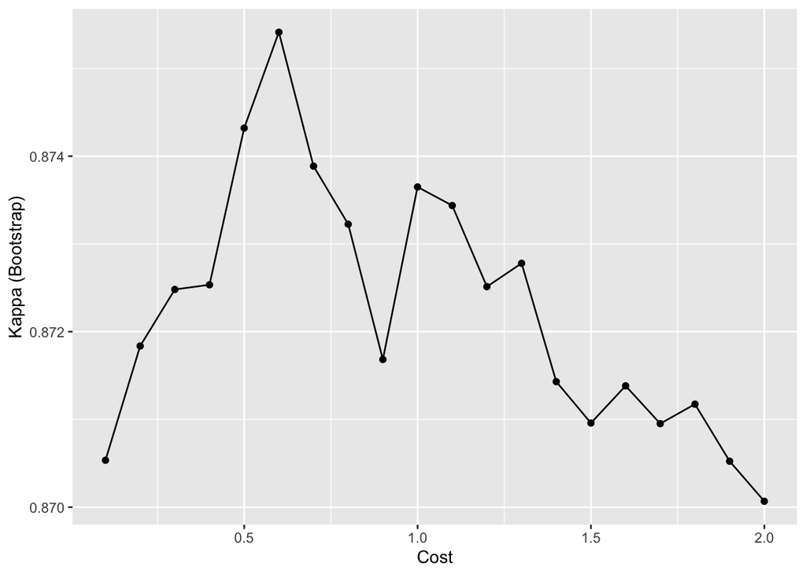

```r
# plot the kappa over the different values for the cost function
ggplot(linearSVM, metric="Kappa")
```

```r
# fit RBF SVM
tg <- data.frame(C=seq(0.1,2,0.1), sigma=rep(0.05, 20))
RBFSVM <- train(x, y, method="svmRadial", tuneGrid=tg)
RBFSVM$results
```

```
##      C sigma  Accuracy     Kappa  AccuracySD    KappaSD
## 1  0.1  0.05 0.9252251 0.8501740 0.009391337 0.01856038
## 2  0.2  0.05 0.9317897 0.8633536 0.010025134 0.01984646
## 3  0.3  0.05 0.9355043 0.8708056 0.009943265 0.01973595
## 4  0.4  0.05 0.9372825 0.8743755 0.009948256 0.01978194
## 5  0.5  0.05 0.9387578 0.8773234 0.008868129 0.01763767
## 6  0.6  0.05 0.9393061 0.8784137 0.009146358 0.01824672
## 7  0.7  0.05 0.9395390 0.8788798 0.008815527 0.01760212
## 8  0.8  0.05 0.9399948 0.8797986 0.008389065 0.01674261
## 9  0.9  0.05 0.9401002 0.8800159 0.008998635 0.01797393
## 10 1.0  0.05 0.9405498 0.8809130 0.009506592 0.01902724
## 11 1.1  0.05 0.9408995 0.8816152 0.009200534 0.01841007
## 12 1.2  0.05 0.9405638 0.8809369 0.008347152 0.01672788
## 13 1.3  0.05 0.9405711 0.8809640 0.008732674 0.01748570
## 14 1.4  0.05 0.9409025 0.8816288 0.009292673 0.01860284
## 15 1.5  0.05 0.9411138 0.8820539 0.008827247 0.01765939
## 16 1.6  0.05 0.9405618 0.8809436 0.009026157 0.01809218
## 17 1.7  0.05 0.9404562 0.8807305 0.008683960 0.01741356
## 18 1.8  0.05 0.9403253 0.8804732 0.009067463 0.01817711
## 19 1.9  0.05 0.9406641 0.8811561 0.008966032 0.01796671
## 20 2.0  0.05 0.9407702 0.8813701 0.009202637 0.01843097
```

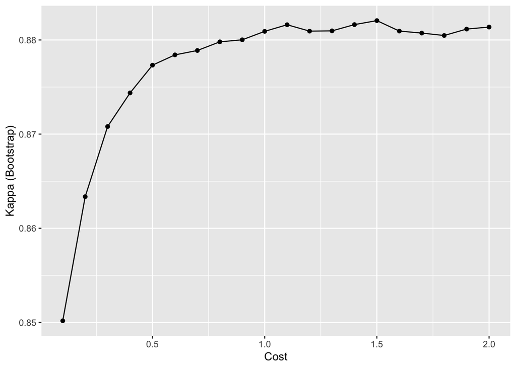

```r
# plot the kappa over the different values for the cost function
ggplot(RBFSVM, metric="Kappa")
```

Now, suppose we want to examine plots of the decision boundary in the feature space. We can only look at two features at a time in a scatter plot. What are the two most important variables for the SVMs (they are the same for both SVMs)?

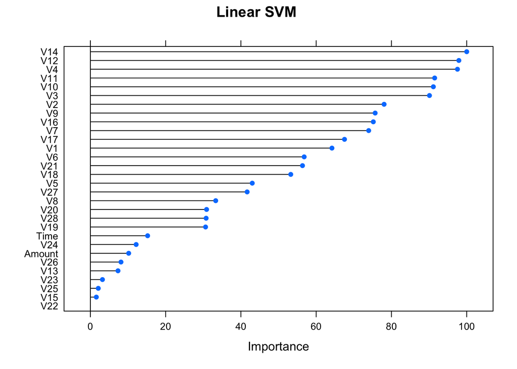

```r
# assess the variable importance for linear SVM
plot(varImp(object=linearSVM),   main="Linear SVM ")
```

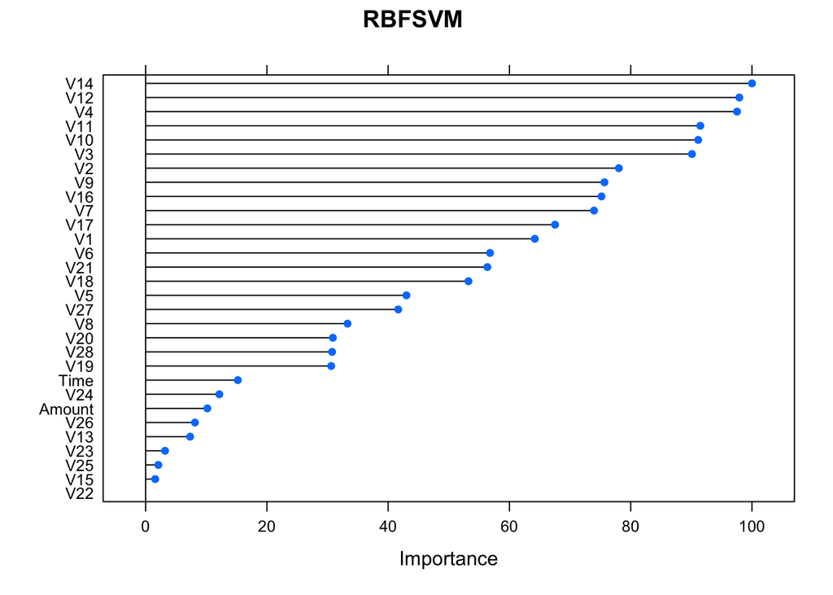

```r
# assess the variable importance for RBF SVM
plot(varImp(object=RBFSVM),   main="RBFSVM ")
```

The plots show that the most important variable are V4, V12 and V14.

### 2

Make a scatterplot for each method that includes: the data points in this two dimensional space, colored by the “0” and “1” prediction, and the decision boundary. In class, we simply used `expand.grid` to build the `newdata` that was fed to `predict`. Start with this approach, using a grid of 40 points from -4 to 4 for the two most important variables, but before you attempt to run `predict` (which would give an error), read further:

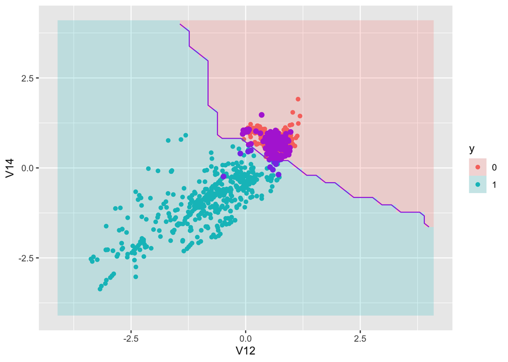

```r
length = 40
grid <- as.data.frame(matrix(NA, nrow = length^2, ncol = ncol(x)))
colnames(grid) = colnames(x)
s <- seq(from=-4,to=4,length=length)
grid2 <- expand.grid(V12=s,V14=s)
grid$V12 <- grid2$V12
grid$V14 <- grid2$V14
preProcValues <- preProcess(x, method = "knnImpute")
grid3 <- predict(preProcValues, grid)
grid4 <- grid3
rsv <- as.data.frame(x[linearSVM$finalModel@SVindex,])
grid3$y <- predict(linearSVM, newdata=grid3)
grid3$yy <- 2*(as.numeric(grid3$y) - 1.5)
ggplot(x, aes(V12,V14,col=y)) + geom_point() +
  geom_point(data=rsv, col="purple", size=2) +
  geom_contour(data=grid3, aes(V12,V14,z=yy), breaks=0, col="purple") +
  geom_raster(data=grid3, aes(V12,V14,fill=y), alpha=.2)
```

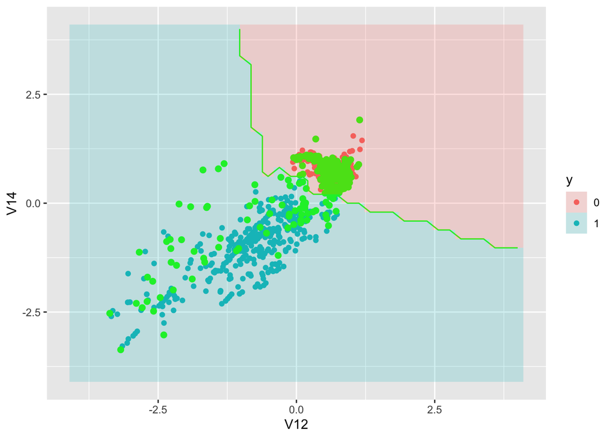

```r
# scatterplot for RBF SVM
rsv <- as.data.frame(x[RBFSVM$finalModel@SVindex,])
grid4$y <- predict(RBFSVM, newdata=grid4)
grid4$yy <- 2*(as.numeric(grid4$y) - 1.5)
ggplot(x, aes(V12,V14,col=y)) + geom_point() +
  geom_point(data=rsv, col="green", size=2) +
  geom_contour(data=grid4, aes(V12,V14,z=yy), breaks=0, col="green") +
  geom_raster(data=grid4, aes(V12,V14,fill=y), alpha=.2)
```

In this case, we have to worry about the other 30 - 2 = 28 variables. If we put in 0’s, this would not be typical observations, and we will get strange results.

Instead, you should put `NA` for the other variables, and use `preProcess` with KNN imputation (alone, don’t re-scale), to impute the other values. Then use this data to run `predict` and define the decision boundary. This is a simpler approach compared to the integration approach taken by `plot.gbm` to produce marginal plots that we saw when we looked at boosting, but it is sufficient to get a sense of the decision boundary in 2D for “typical” values of the other covariates.

### 3

Do you see a big difference in the decision boundary for linear vs RBF SVM?

There is no big difference between the decisoin boundary from the plots.